# **Project - Classification and Hypothesis Testing: Hotel Booking Cancellation Prediction**

### **Question 7: Random Forest (4 Marks)**

#### **Question 7.1: Build a Random Forest Model (1 Mark)**

```python
# One-hot encode categorical features
data = pd.get_dummies(data)

# Split into X and y
X = data.drop('booking_status', axis=1)
y = data['booking_status']

# Split into train and test sets
X_train, X_test, y_train, y_test = train_test_split(X, y, test_size=0.2, random_state=42)

# Create and fit RandomForestClassifier
rf_estimator = RandomForestClassifier(n_estimators=100, random_state=42)
rf_estimator.fit(X_train, y_train)

# Evaluate on test set
accuracy = rf_estimator.score(X_test, y_test)
```

#### **Question 7.2: Check the performance of the model on the train and test data (2 Marks)**

```
              precision    recall  f1-score   support

           0       0.91      0.95      0.93      4839
           1       0.89      0.82      0.85      2416

    accuracy                           0.91      7255
   macro avg       0.90      0.88      0.89      7255
weighted avg       0.90      0.91      0.90      7255
```

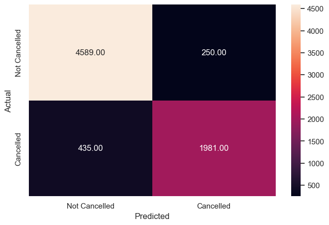

```python
y_pred_test_rf = rf_estimator.predict(X_test)
y_pred_tuned = rf_estimator.predict(X_test)

metrics_score(y_test, y_pred_tuned)
```

```
              precision    recall  f1-score   support

           0       0.91      0.95      0.93      4839
           1       0.89      0.82      0.85      2416

    accuracy                           0.91      7255
   macro avg       0.90      0.88      0.89      7255
weighted avg       0.90      0.91      0.90      7255
```

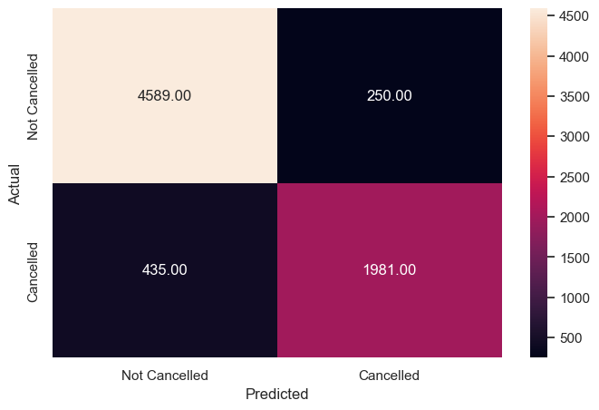

```python
# Remove _________ and complete the code

y_pred_test_rf = rf_estimator.predict(X_test)

metrics_score(y_test, y_pred_test_rf)
```

#### **Question 7.3: What are some important features based on the Random Forest? (1 Mark)**

Let's check the feature importance of the Random Forest

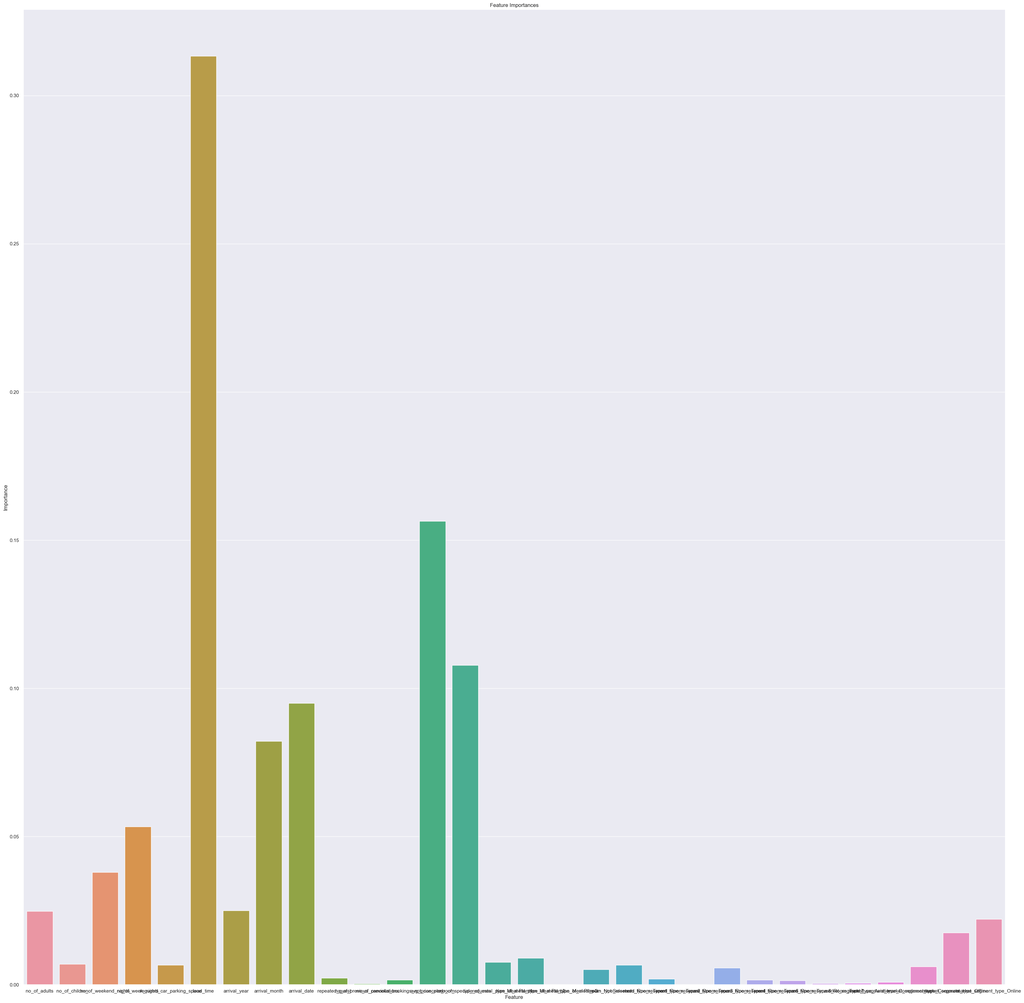

```python
y = data['booking_status']

# Assuming X and y are your feature matrix and target vector, respectively
rf_estimator = RandomForestClassifier()
rf_estimator.fit(X, y)

importances = rf_estimator.feature_importances_
columns = X.columns
importance_df = pd.DataFrame({'Feature': columns, 'Importance': importances})

plt.figure(figsize=(40, 40))
sns.barplot(x=importance_df.Feature, y=importance_df.Importance)
plt.title('Feature Importances')
plt.show()
```

**Write your answers here:**

The most Important feature is lead time

### **Question 8: Conclude ANY FOUR key takeaways for business recommendations (4 Marks)**

**Write your answers here:**

The company should maintain loyal customers.

The company should increase the amount of lead time

The company should increase the amount of parking space